# An introduction to the baysc package

### 2.3.4 Plot distribution of classes

To examine how common the classes are in the broader population, the `plot_class_dist()` function displays boxplots for the estimated proportion of the population belonging to each class (i.e., latent class membership probabilities, $\pi$) across the iterations of the MCMC sampler.

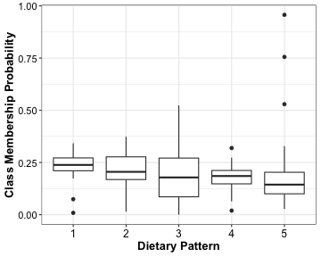

Figure: Distribution of latent classes in the population

```r
plot_class_dist(res = res_swolca_adjust)
```

```r
# Median estimated population class proportions
round(res_swolca_adjust$estimates_adjust$pi_med, 3)
```

```
## [1] 0.251 0.216 0.188 0.195 0.151
```

### 2.3.5 Display distribution of additional variables across classes

We can create a table to examine the distribution of additional variables across the derived classes. In this example, we create a table of the distribution of age, race and ethnicity, physical activity, and smoking status across five derived dietary patterns. For these distributions, the data are weighted so that the proportions are representative of the distribution of the variables across classes in the population. To see the proportions in the sample, specify `population = FALSE`. The proportion of the classes in the population is also displayed in this table, using the same data as the `plot_class_dist()` function.

```r
# Convert class assignment variable from model output to a factor
c_all <- factor(res_swolca_adjust$estimates_adjust$c_all,
                levels = 1:5, labels = paste0("C", 1:5))
# Create dataframe containing covariates to view distribution across classes,
# editing the labels for the variable names and levels
cov_df <- data_nhanes %>%
  select(RIDAGEYR, age_cat, racethnic, smoker, physactive) %>%
  rename(Age = RIDAGEYR) %>%
  mutate(Age_Group = factor(age_cat, levels = c(1, 2, 3),
                            labels = c("[20, 40)", "[40, 60)", ">=60")),
         Race_Ethnicity = factor(racethnic, c(1, 2, 3, 4, 5),
                                 labels = c("NH White", "NH Black", "NH Asian",
                                            "Hispanic/Latino", "Other/Mixed")),
         Current_Smoker = factor(smoker, levels = c(0, 1), labels = c("No", "Yes")),
         Physical_Activity = factor(physactive, levels = c("Inactive", "Active")),
         .keep = "unused")
# Obtain table displaying distribution of variables across classes
output_df <- vars_across_class(c_all = c_all, cov_df = cov_df,
                              sampling_wt = sampling_wt, stratum_id = stratum_id,
                              cluster_id = cluster_id, digits = 1,
                              col_props = TRUE, res = res_swolca_adjust)
knitr::kable(output_df)
```

| Variable | Level | C1 | C2 | C3 | C4 | C5 | Overall |
| --- | --- | --- | --- | --- | --- | --- | --- |
| N: % (posterior SD %) |  | 23.8 (5.9) | 21.1 (8.1) | 18.9 (13.4) | 18.1 (5.1) | 18.0 (16.6) |  |
| n: % |  | 25.2 | 23.1 | 13.3 | 21.5 | 17.0 |  |
| Age: Mean |  | 44.0 | 43.8 | 47.0 | 50.1 | 47.4 | 46.2 |
| Age_Group: % | [20, 40) | 46.3 | 49.5 | 37.8 | 31.1 | 41.9 | 41.9 |
|  | [40, 60) | 30.7 | 26.7 | 38.6 | 40.5 | 27.4 | 32.6 |
|  | >=60 | 23.0 | 23.8 | 23.5 | 28.5 | 30.7 | 25.5 |
| Race_Ethnicity: % | NH White | 51.1 | 44.1 | 64.0 | 46.7 | 41.9 | 49.3 |
|  | NH Black | 17.6 | 16.4 | 10.7 | 15.5 | 20.8 | 16.3 |
|  | NH Asian | 3.1 | 5.2 | 2.3 | 7.5 | 11.4 | 5.6 |
|  | Hispanic/Latino | 23.0 | 28.7 | 20.6 | 21.8 | 22.7 | 23.6 |
|  | Other/Mixed | 5.1 | 5.6 | 2.3 | 8.5 | 3.2 | 5.2 |
| Current_Smoker: % | No | 74.4 | 78.4 | 64.5 | 71.1 | 77.3 | 73.5 |
|  | Yes | 25.6 | 21.6 | 35.5 | 28.9 | 22.7 | 26.5 |
| Physical_Activity: % | Inactive | 45.5 | 44.5 | 44.4 | 47.1 | 42.9 | 45.1 |
|  | Active | 54.5 | 55.5 | 55.6 | 52.9 | 57.1 | 54.9 |

Parameters used for `vars_across_class()`:

- `c_all`: nx1 factor vector of latent class assignments, typically obtained from the `swolca()`, `wolca()`, `swolca_var_adjust()` or `wolca_var_adjust()` functions. Factor levels should be labeled with the names that are to appear in the output table.
- `cov_df`: Dataframe with $n$ rows containing sociodemographic variables. Factors should be labeled with the names and levels that are to appear in the output table.
- `sampling_wt`: nx1 vector of survey sampling weights.
- `cluster_id`: nx1 vector of cluster indicators for clustered sampling.
- `stratum_id`: nx1 vector of stratum indicators.
- `digits = 1`: Round table output to 1 decimal place (default).
- `col_props = TRUE`: Factor variables should have percentages reported as column totals (default), displaying the population $%$ in each category for a given class. If `FALSE`, row totals are used instead and display the population $%$ in each class for a given category.
- `res = res_swolca_adjust`: Results from `swolca_var_adjust()` to be used to calculate the percentage of individuals falling into each class in the population, accounting for survey design.

### 2.3.6 Summarize and plot the exposure-outcome relationship

To examine how the latent classes relate to the binary outcome of interest, we can first convert the regression coefficients from factor reference coding to the more commonly used reference cell coding and display a summary of the parameter estimates. One advantage of factor reference coding is it allows the reference class to be determined post-hoc, so any class can be chosen as the reference level for which to display regression coefficients without having to re-run the model. Simply run `reorder_classes()` with the desired reference level as the first class in `new_order`, and then run `get_regr_coefs()` as shown below. Note that this is *not* possible with the two-step `wolca_svyglm()` method. Please re-run `wolca_svyglm()` with the desired reference level refactoring

In this example, we display a summary of the probit regression coefficients using class 1 as the reference. We also display the 95% credible intervals (`ci_level = 0.95`) and round the table values to two decimal points (`digits = 2`). To save space, we only display the first 10 regression coefficients in the output.

```r
# Get table of regression coefficients
regr_coefs <- get_regr_coefs(res = res_swolca_adjust, ci_level = 0.95, digits = 2)
regr_coefs[1:10, ]
```

```
##      Covariate Estimate    LB    UB P(xi > 0)
## 1  (Intercept)    -1.13 -1.48 -0.72     <0.01
## 2       c_all2    -0.10 -1.19  1.24      0.42
## 3       c_all3     0.08 -0.75  1.26      0.62
## 4       c_all4     0.28 -0.57  1.09      0.66
## 5       c_all5     0.24 -2.36  1.76      0.62
## 6     age_cat2     1.09  0.82  1.38      1.00
## 7     age_cat3     2.13  1.47  2.58      1.00
## 8   racethnic2     0.44 -0.13  1.08      0.94
## 9   racethnic3     0.06 -0.59  1.12      0.56
## 10  racethnic4    -0.16 -0.48  0.20      0.20
```

To visualize this in the form of a boxplot, use the `plot_regr_coefs()` function.

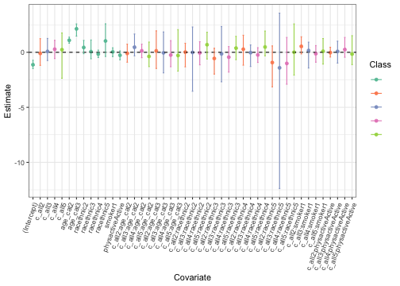

Figure: Outcome regression coefficients

```r
plot_regr_coefs(regr_coefs = regr_coefs, res = res_swolca_adjust)
```

If we want to change the labels for the covariates, we can do so with the `cov_labels` argument. We can also modify other aspects of the plot, such as moving the legend position, by using typical arguments from the `ggplot2` package.

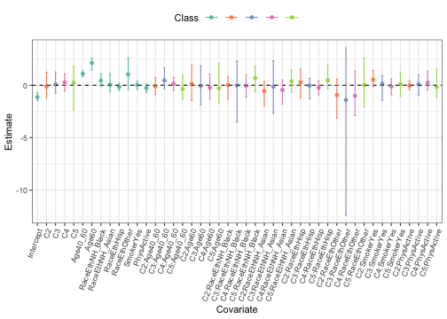

Figure: Outcome regression coefficients with custom labels

```r
# Define new vector of covariate labels
class_dummies <- paste0("C", 2:5)
age_dummies <- paste0("Age", c("40_60", "60"))
race_dummies <- paste0("RaceEth", c("NH_Black", "NH_Asian", "Hisp", "Other"))
cov_labels <- c("Intercept", class_dummies, age_dummies, race_dummies,
                "SmokerYes", "PhysActive",
                paste0(class_dummies, ":", rep(age_dummies, each = 4)),
                paste0(class_dummies, ":", rep(race_dummies, each = 4)),
                paste0(class_dummies, ":", rep("SmokerYes", each = 4)),
                paste0(class_dummies, ":", rep("PhysActive", each = 4)))
# Get plot of regression coefficient estimates and error bars
regr_plot <- plot_regr_coefs(regr_coefs = regr_coefs, res = res_swolca_adjust,
                             cov_labels = cov_labels)
# Display plot with legend above
regr_plot + ggplot2::theme(legend.position = "top")
```

Alternatively, for categorical covariates, rather than plotting the regression coefficients, we can evaluate the probit regression model at all levels of the covariate and then plot the conditional probability of the outcome using the `plot_outcome_probs()` function. This displays the probability of the outcome for the different classes, evaluated at all levels of a categorical covariate, with all other covariates evaluated at their reference level. In this example, we plot the probability of hypertension for the five dietary patterns across levels of age, with error bars for the 95% credible intervals.

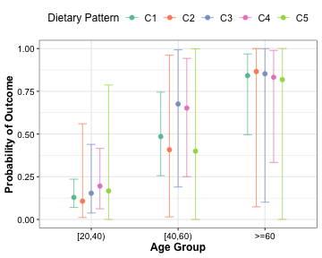

Figure: Outcome probabilities for levels of a categorical covariate

```r
class_labels <- paste0("C", 1:5)
age_cat_categs <- c("[20,40)", "[40,60)", ">=60")
plot_outcome_probs(res = res_swolca_adjust, cov_name = "age_cat",
                   cov_labels = age_cat_categs, class_labels = class_labels,
                   x_title = "Age Group")
```

We can also display the probability of outcome plots for two categorical covariates at the same time, assessing for any interactions. We can add lines connecting the points between levels of “Age” using the `add_lines = TRUE` parameter, and remove the error bars by setting `ci_level = NULL`.

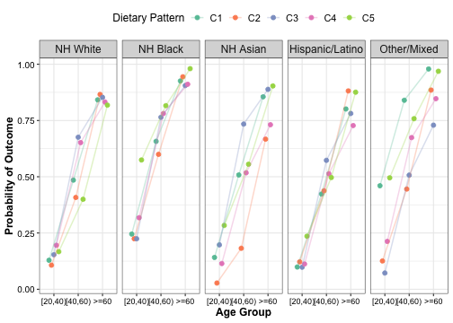

Figure: Outcome probabilities for levels of two categorical covariates

```r
racethnic_categs <- c("NH White", "NH Black", "NH Asian", "Hispanic/Latino",
                      "Other/Mixed")
p <- plot_outcome_probs(res = res_swolca_adjust, cov_name = c("age_cat", "racethnic"),
                        cov_labels = list(age_cat_categs, racethnic_categs),
                        class_labels = class_labels, x_title = "Age Group",
                        ci_level = NULL, add_lines = TRUE)
print(p + ggplot2::theme(axis.text.x = ggplot2::element_text(size = 9)))
```

## 2.4 Obtain performance diagnostics and additional output

Total runtime and the deviance information criteria (DIC) goodness-of-fit measure for model selection are available within the package using the following functions.

```r
# Runtime
res_swolca_adjust$runtime
```

```
## Time difference of 10.97209 mins
```

```r
# Deviance information criteria for model goodness-of-fit
get_dic(res_swolca_adjust)
```

```
## [1] 125463.1
```

A list of the raw posterior point and interval estimates for all parameters can be obtained. We set a credible interval level of 95% and round the estimates to two digits. The parameters consist of:

- $\pi_1,\ldots, \pi_K$: latent class membership probabilities for each of the $K$ underlying classes. $\pi$ parameters are returned in a vector of length $K$.
- $\theta_{jk1}, \ldots, \theta_{jkR_j}$: exposure level probabilities ranging from 1 to $R_j$, where $R_j$ is the number of exposure levels for item $j$ out of a total of $J$ items, and $k=1,\ldots, K$. $\theta$ parameters are returned in a $JxKxR$-dimensional array.
- $\xi_{k1}, \ldots, \xi_{kQ}$: coefficients in the binary outcome probit regression with $Q$ covariates. $\xi$ parameters are returned in a $KxQ$-dimensional matrix.

```r
# Extract summary of parameter estimates
estimates_df <- summarize_res(res = res_swolca_adjust, ci_level = 0.95, digits = 2)
# First few pi estimates
estimates_df[1:3, ]
```

```
##   Parameter Estimate Lower Bound Upper Bound
## 1      pi_1     0.25        0.10        0.33
## 2      pi_2     0.22        0.03        0.34
## 3      pi_3     0.19        0.02        0.47
```

```r
# First few theta estimates
estimates_df[6:9, ]
```

```
##     Parameter Estimate Lower Bound Upper Bound
## 6 theta_1_1_1     0.65        0.43        0.76
## 7 theta_2_1_1     0.46        0.29        0.59
## 8 theta_3_1_1     0.44        0.38        0.52
## 9 theta_4_1_1     0.58        0.41        0.70
```

```r
# First few xi estimates
estimates_df[566:569, ]
```

```
##     Parameter Estimate Lower Bound Upper Bound
## 566    xi_1_1    -1.13       -1.48       -0.72
## 567    xi_2_1    -1.24       -2.27        0.15
## 568    xi_3_1    -1.02       -1.78       -0.15
## 569    xi_4_1    -0.86       -1.54       -0.21
```

We can also extract the MCMC iteration values for all parameters that were obtained through the MCMC sampler. For SWOLCA, this will be $\pi$, $\theta$, and $\xi$. For WOLCA, this will be only $\pi$ and $\theta$.

```r
# Extract parameter MCMC iteration values
param_mcmc <- get_param_mcmc(res_swolca_adjust)
# Display first 10 iterations of pi
param_mcmc$pi_mcmc[1:10, ]
```

```
##           pi_1       pi_2         pi_3      pi_4       pi_5
## 1  0.199337680 0.29798426 0.1279449684 0.2206540 0.15407908
## 2  0.256967542 0.30446362 0.2021383390 0.1572870 0.07914354
## 3  0.263425322 0.08413522 0.4648721743 0.1231027 0.06446456
## 4  0.221394758 0.23644027 0.1722512104 0.2167745 0.15313927
## 5  0.269240234 0.18652288 0.2918798644 0.1791225 0.07323449
## 6  0.311260177 0.19111240 0.2805098911 0.1457299 0.07138768
## 7  0.008695988 0.01466584 0.0003048905 0.0195115 0.95682179
## 8  0.196751600 0.24555358 0.0486972000 0.2042066 0.30479104
## 9  0.277954303 0.22683991 0.1138511948 0.2062676 0.17508698
## 10 0.245779276 0.27931692 0.0645889321 0.1847761 0.22553878
```

Bayesian model diagnostics such as traceplots and autocorrelation plots can be created for all estimates to examine whether the MCMC sampler has adequately converged. For example, we display code to create traceplots and autocorrelation plots for the five class membership probability parameters, $\pi_1,\ldots, \pi_5$.

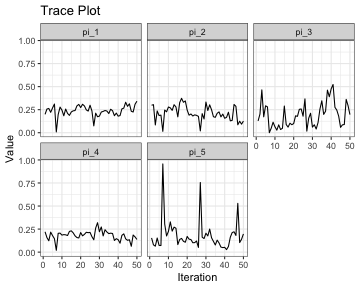

Figure: Traceplots for pi

```r
# Specify selection of pi_1 to pi_5
param_names <- colnames(param_mcmc$pi_mcmc)
# Create traceplots
create_traceplot(param_mcmc = param_mcmc, param_names = param_names)
```

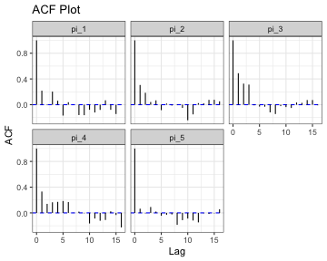

Figure: ACF plots for pi

```r
# Create ACF plots
create_acfplot(param_mcmc = param_mcmc, param_names = param_names)
```

# 3 References

Lumley, Thomas. 2023. “Survey: Analysis of Complex Survey Samples.”

Muthén, Bengt, and Linda K Muthén. 2000. “Integrating Person-Centered and Variable-Centered Analyses: Growth Mixture Modeling with Latent Trajectory Classes.” *Alcoholism: Clinical and Experimental Research* 24 (6): 882–91.

National Center for Health Statistics. 2023. “National Health and Nutrition Examination Survey Home Page.” Centers for Disease Control; Prevention, National Center for Health Statistics, Atlanta, GA. https://www.cdc.gov/nchs/nhanes.htm.

Nylund-Gibson, Karen, Ryan P Grimm, and Katherine E Masyn. 2019. “Prediction from Latent Classes: A Demonstration of Different Approaches to Include Distal Outcomes in Mixture Models.” *Structural Equation Modeling: A Multidisciplinary Journal* 26 (6): 967–85.

Savitsky, Terrance D, and Daniell Toth. 2016. “Bayesian Estimation Under Informative Sampling.” *Electronic Journal of Statistics* 10 (1): 1677–1708.

Stephenson, Briana JK, Stephanie M Wu, and Francesca Dominici. 2023. “Identifying dietary consumption patterns from survey data: a Bayesian nonparametric latent class model.” *Journal of the Royal Statistical Society Series A: Statistics in Society*, December, qnad135. https://doi.org/10.1093/jrsssa/qnad135.

Wang, Meng-Cheng, Qiaowen Deng, Xiangyang Bi, Haosheng Ye, and Wendeng Yang. 2017. “Performance of the Entropy as an Index of Classification Accuracy in Latent Profile Analysis: A Monte Carlo Simulation Study.” *Acta Psychologica Sinica*.

Weller, Bridget E, Natasha K Bowen, and Sarah J Faubert. 2020. “Latent Class Analysis: A Guide to Best Practice.” *Journal of Black Psychology* 46 (4): 287–311.

Williams, Matthew R, and Terrance D Savitsky. 2021. “Uncertainty Estimation for Pseudo-Bayesian Inference Under Complex Sampling.” *International Statistical Review* 89 (1): 72–107.

Wu, Stephanie M, Matthew R Williams, Terrance D Savitsky, and Briana JK Stephenson. 2024. “Derivation of Outcome-Dependent Dietary Patterns for Low-Income Women Obtained from Survey Data Using a Supervised Weighted Overfitted Latent Class Analysis.” *Biometrics* 80 (4): ujae122.

# 4 Supplementary installation instructions

For users experiencing a “library ‘gfortran’ not found” error message during installation, additional steps are needed to install the `baysc` package. This is a compiler configuration issue that can arise when using Rcpp-dependent packages on Mac computers with Apple silicon (e.g., M1, M2, M3). Please follow the instructions listed below, adapted from instructions posted at [https://stackoverflow.com/questions/70638118/configuring-compilers-on-apple-silicon-m1-m2-m3-for-rcpp-and-other-tool)](https://stackoverflow.com/questions/70638118/configuring-compilers-on-apple-silicon-m1-m2-m3-for-rcpp-and-other-tool).

1. Download an R binary from CRAN at this link: https://cran.r-project.org/bin/macosx/. Select the binary built for Apple silicon (M1-M3), which will typically the top link on the left under “Latest release”, and install.
2. Go through the instructions to install R, entering in passwords if necessary.
3. Install Xcode by opening Terminal and running the following in the command line: `sudo xcode-select --install` . This will install the latest release version of Apple’s Command Line Tools for Xcode, which includes Apple Clang.
4. Download the GNU Fortran binary .tar.xz file at this link: https://github.com/R-macos/gcc-12-branch/releases/tag/12.2-darwin-r0. Install GNU fortran by running the following code in the command line:

```
curl -LO https://github.com/R-macos/gcc-12-branch/releases/download/12.2-darwin-r0/gfortran-12.2-darwin20-r0-universal.tar.xz
sudo tar xvf gfortran-12.2-darwin20-r0-universal.tar.xz -C /
sudo ln -sfn $(xcrun --show-sdk-path) /opt/gfortran/SDK
```

5. Check your Apple Clang version by running the following in the command line: `clang --version`.
6. Download OpenMP at https://mac.r-project.org/openmp/ by clicking on the Release.tar.gz link corresponding to your Apple Clang version.
7. Install OpenMP by running the following in the command line, making sure to include the correct version. For example, for Apple clang version 15.0.0 (i.e., clang 1500.x), the corresponding OpenMP version is *16.0.4*, so the commands would be:

```
curl -LO https://mac.r-project.org/openmp/openmp-16.0.4-darwin20-Release.tar.gz
sudo mkdir -p /opt/R/$(uname -m)
sudo tar -xvf openmp-16.0.4-darwin20-Release.tar.gz --strip-components=2 -C /opt/R/$(uname -m)
```

8. Navigate to the R Makevars file by running in command line: `cd ~/.R/Makevars`. If the file does not exist, create it by running `mkdir ~/.R/Makevars`.
9. In command line, run `vi`, add the below lines to the file, then save and exit out of the file by typing `ESC` followed by `:wq`.

```
CPPFLAGS += -Xclang -fopenmp
LDFLAGS += -lomp
```

10. Retry the `baysc` package installation by running `devtools::install_github("smwu/baysc")` in R.